# Building Izhikevich Neurons From Scratch

Author: Matthew J. Crossley

Last update: 24 April, 2026

## Tutorial goals

By the end, you should be comfortable with four ideas:

- A neuron can be thought of as a time-evolving system with state variables.
- As with other dynamical systems, we think of the behaviour of this system in terms of its rate of change (i.e., Euler’s method).
- A recovery variable can change excitability over time.
- The same Izhikevich equation can show different firing patterns when its parameters change.

## Relevance to your final project

For your final projects, you will use spiking neuron models to build a small basal ganglia model and apply that model to different kinds of learning scenarios. This tutorial prepares you for that by making the single-neuron model feel familiar before it becomes one component inside a larger circuit.

## The repeated pattern

Every simulation in this tutorial has the same basic structure:

1. Choose a time step, `dt`, and a total duration, `T`.
2. Build a time vector, `t`.
3. Allocate arrays before the loop.
4. Set initial conditions.
5. Update the state one time step at a time.
6. Plot the input and response.

```python
import numpy as np
import matplotlib.pyplot as plt
```

## 1. A passive membrane with Euler updates

Start with the simplest possible membrane model:

$$\frac{dv}{dt} = \frac{-(v - v_{rest}) + R I}{\tau}$$

The voltage moves toward a target set by the resting potential and the input current. The parameter `tau` controls how quickly it moves. Note that in other tutorials, textbooks, or papers, `tau` may refer to the sample time step, not the membrane time constant. Here we use `dt` for the sample time step and `tau` for the membrane time constant.

### Current pattern: sustained step currents

First, compare several sustained positive current steps.

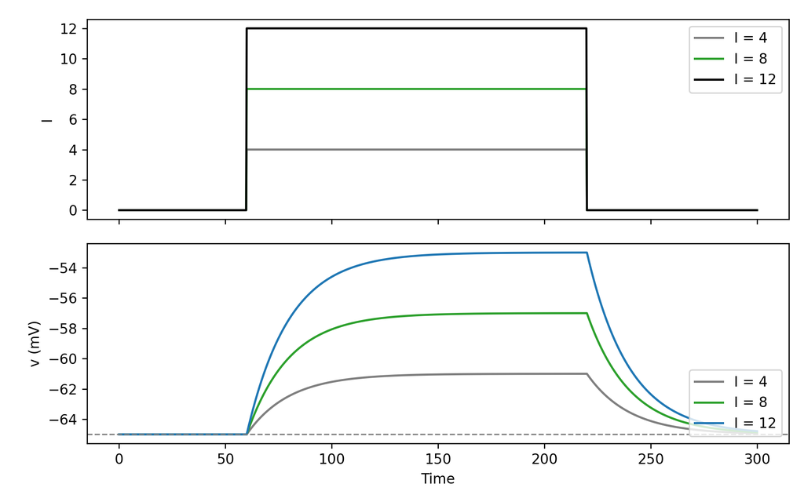

```python
T = 300.0
dt = 0.25
t = np.arange(0, T + dt, dt)
n = t.size

v_rest = -65.0
tau = 20.0
R = 1.0

I = np.zeros((3, n))
I[0, (t >= 60) & (t < 220)] = 4.0
I[1, (t >= 60) & (t < 220)] = 8.0
I[2, (t >= 60) & (t < 220)] = 12.0

v = np.zeros((3, n))
dvdt = np.zeros((3, n))
v[:, 0] = v_rest

for i in range(n - 1):
    for k in range(3):
        dvdt[k, i] = (-(v[k, i] - v_rest) + R * I[k, i]) / tau
        v[k, i + 1] = v[k, i] + dvdt[k, i] * dt

fig, ax = plt.subplots(2, 1, sharex=True)
ax[0].plot(t, I[0], label="I = 4", color="tab:gray")
ax[0].plot(t, I[1], label="I = 8", color="tab:green")
ax[0].plot(t, I[2], label="I = 12", color="black")
ax[0].set_ylabel("I")
ax[0].legend(loc="upper right")

ax[1].plot(t, v[0], label="I = 4", color="tab:gray")
ax[1].plot(t, v[1], label="I = 8", color="tab:green")
ax[1].plot(t, v[2], label="I = 12", color="tab:blue")
ax[1].axhline(v_rest, color="tab:gray", linestyle="--", linewidth=1)
ax[1].set_ylabel("v (mV)")
ax[1].set_xlabel("Time")
ax[1].legend(loc="lower right")

plt.tight_layout()
plt.show()
```

#### Check your understanding

- Why does voltage not jump instantly to its new value?
- What does changing `tau` from `20.0` to `5.0` do? Does it change the final voltage, the speed of approach, or both?

**Show solution**

Voltage changes gradually because each Euler step only moves part of the way according to `dvdt * dt`. Changing `tau` changes the speed, not the final steady value for a fixed current. A smaller `tau` makes the response faster.

### Current pattern: positive then negative pulses

Use positive and negative pulses to make the stable baseline visible.

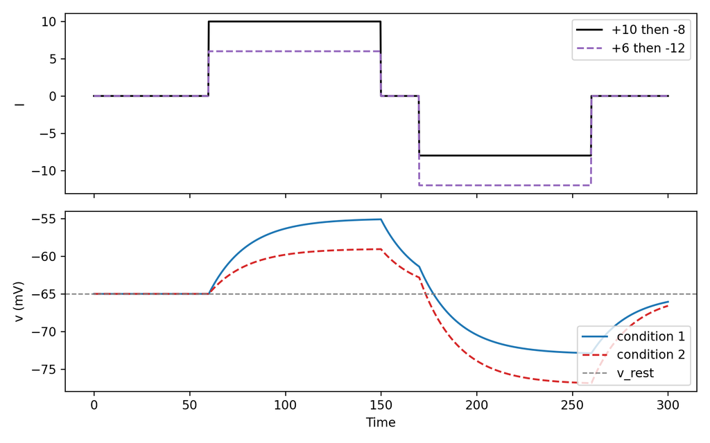

```python
I = np.zeros((2, n))
I[0, (t >= 60) & (t < 150)] = 10.0
I[0, (t >= 170) & (t < 260)] = -8.0
I[1, (t >= 60) & (t < 150)] = 6.0
I[1, (t >= 170) & (t < 260)] = -12.0

v = np.zeros((2, n))
v[:, 0] = v_rest

for i in range(n - 1):
    for k in range(2):
        dvdt_now = (-(v[k, i] - v_rest) + R * I[k, i]) / tau
        v[k, i + 1] = v[k, i] + dvdt_now * dt

fig, ax = plt.subplots(2, 1, sharex=True)
ax[0].plot(t, I[0], color="black", label="+10 then -8")
ax[0].plot(t, I[1], color="tab:purple", linestyle="--", label="+6 then -12")
ax[0].set_ylabel("I")
ax[0].legend(loc="upper right")

ax[1].plot(t, v[0], color="tab:blue", label="condition 1")
ax[1].plot(t, v[1], color="tab:red", linestyle="--", label="condition 2")
ax[1].axhline(v_rest, color="tab:gray", linestyle="--", linewidth=1, label="v_rest")
ax[1].set_ylabel("v (mV)")
ax[1].set_xlabel("Time")
ax[1].legend(loc="lower right")

plt.tight_layout()
plt.show()
```

#### Quick measurement

Use the output above to answer: when the input returns to zero, what value does voltage move back toward?

**Show solution**

It moves back toward `v_rest = -65 mV`. In this passive model, `v_rest` is the stable equilibrium when `I = 0`.

## 2. Add a slow recovery variable

Real neurons have processes that change more slowly than membrane voltage. We will introduce a second state variable, `u`, that tracks slow recovery.

For this teaching step, use a baseline-centered form:

$$\frac{dv}{dt} = \frac{-(v - v_{rest}) - u + I}{\tau_v}$$

$$\frac{du}{dt} = a(b(v - v_{rest}) - u)$$

This is not yet the canonical Izhikevich model. It is a stepping stone that lets us see how two state variables can influence one another. The variable `v` is the membrane voltage. The variable `u` is a slower recovery process. The important point is that the equations are coupled: `u` appears in the equation for `dv/dt`, and `v` appears in the equation for `du/dt`.

In the voltage equation, `-u` means that recovery pushes back against depolarization. If `u` becomes larger, it subtracts more from the voltage update, so `v` rises less quickly or falls back down. In the recovery equation, `b(v - v_rest)` means that the recovery variable responds to voltage. When `v` is above rest, `(v - v_rest)` is positive, so `u` is pulled upward. When `v` is below rest, `(v - v_rest)` is negative, so `u` is pulled downward.

The parameter `a` controls how quickly `u` moves toward its target. A small `a` makes recovery slow; a larger `a` makes recovery track voltage more quickly. The parameter `b` controls how strongly voltage affects the target value for `u`. Larger `b` means the same voltage deflection produces a larger recovery response.

Notice the different signs on `(v - v_rest)`. In the voltage equation, `-(v - v_rest)` is a leak term. If voltage is above rest, this term is negative and pulls voltage back down; if voltage is below rest, this term is positive and pulls voltage back up. In the recovery equation, `+(v - v_rest)` appears inside `b(v - v_rest)` because depolarization should build recovery. So the same voltage deflection has two roles: it is opposed by the membrane leak in the fast voltage equation, and it drives the slower recovery variable in the `u` equation.

### Current pattern: sustained step currents

First, compare several sustained positive current steps.

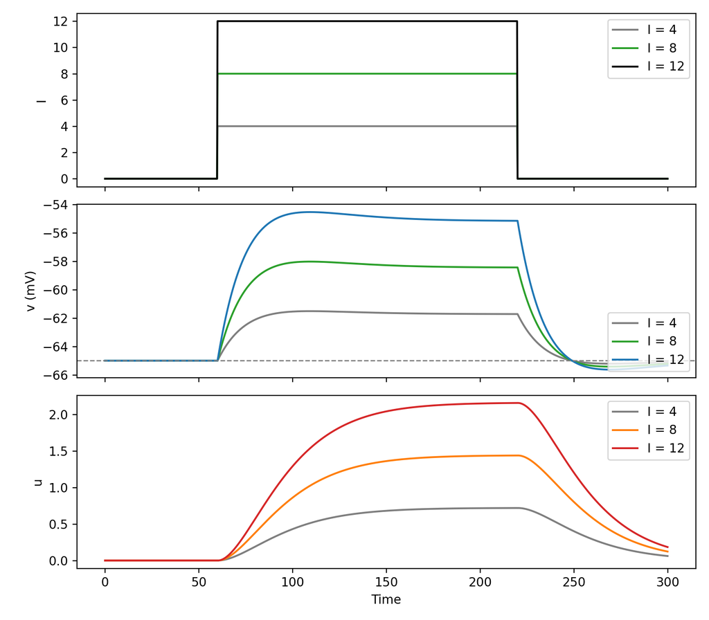

```python
T = 300.0
dt = 0.25
t = np.arange(0, T + dt, dt)
n = t.size

v_rest = -65.0
a = 0.03
b = 0.22
tau_v = 15.0

I = np.zeros((3, n))
I[0, (t >= 60) & (t < 220)] = 4.0
I[1, (t >= 60) & (t < 220)] = 8.0
I[2, (t >= 60) & (t < 220)] = 12.0

v = np.zeros((3, n))
u = np.zeros((3, n))
v[:, 0] = v_rest
u[:, 0] = 0.0

for i in range(n - 1):
    for k in range(3):
        dvdt = (-(v[k, i] - v_rest) - u[k, i] + I[k, i]) / tau_v
        dudt = a * (b * (v[k, i] - v_rest) - u[k, i])
        v[k, i + 1] = v[k, i] + dvdt * dt
        u[k, i + 1] = u[k, i] + dudt * dt

fig, ax = plt.subplots(3, 1, sharex=True, figsize=(8, 7))
ax[0].plot(t, I[0], label="I = 4", color="tab:gray")
ax[0].plot(t, I[1], label="I = 8", color="tab:green")
ax[0].plot(t, I[2], label="I = 12", color="black")
ax[0].set_ylabel("I")
ax[0].legend(loc="upper right")

ax[1].plot(t, v[0], label="I = 4", color="tab:gray")
ax[1].plot(t, v[1], label="I = 8", color="tab:green")
ax[1].plot(t, v[2], label="I = 12", color="tab:blue")
ax[1].axhline(v_rest, color="tab:gray", linestyle="--", linewidth=1)
ax[1].set_ylabel("v (mV)")
ax[1].legend(loc="lower right")

ax[2].plot(t, u[0], label="I = 4", color="tab:gray")
ax[2].plot(t, u[1], label="I = 8", color="tab:orange")
ax[2].plot(t, u[2], label="I = 12", color="tab:red")
ax[2].set_ylabel("u")
ax[2].set_xlabel("Time")
ax[2].legend(loc="upper right")

plt.tight_layout()
plt.show()
```

#### Check your understanding

- Which variable changes faster, `v` or `u`?
- When current is on, why does `u` increase?
- What would happen if you made `a` larger?

**Show solution**

`v` changes faster because it is the immediate membrane variable. `u` increases because depolarization makes `b * (v - v_rest)` positive, so `u` slowly moves upward. Increasing `a` makes `u` track voltage more quickly, so recovery feedback arrives sooner.

### Current pattern: slow and fast ramps

Now compare a slow ramp and a fast ramp with the same peak input.

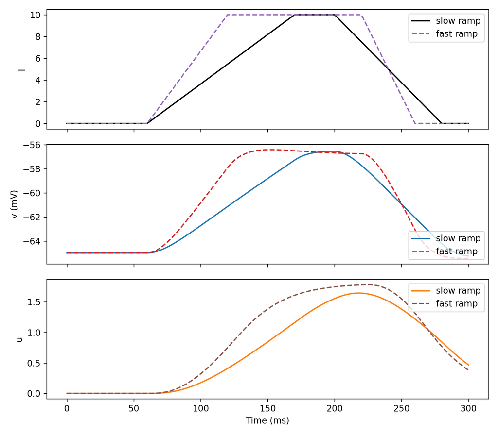

```python
I = np.zeros((2, n))

up1 = (t >= 60) & (t < 170)
hold1 = (t >= 170) & (t < 200)
down1 = (t >= 200) & (t < 280)
I[0, up1] = np.linspace(0.0, 10.0, up1.sum(), endpoint=False)
I[0, hold1] = 10.0
I[0, down1] = np.linspace(10.0, 0.0, down1.sum(), endpoint=False)

up2 = (t >= 60) & (t < 120)
hold2 = (t >= 120) & (t < 220)
down2 = (t >= 220) & (t < 260)
I[1, up2] = np.linspace(0.0, 10.0, up2.sum(), endpoint=False)
I[1, hold2] = 10.0
I[1, down2] = np.linspace(10.0, 0.0, down2.sum(), endpoint=False)

v = np.zeros((2, n))
u = np.zeros((2, n))
v[:, 0] = v_rest

for i in range(n - 1):
    for k in range(2):
        dvdt = (-(v[k, i] - v_rest) - u[k, i] + I[k, i]) / tau_v
        dudt = a * (b * (v[k, i] - v_rest) - u[k, i])
        v[k, i + 1] = v[k, i] + dvdt * dt
        u[k, i + 1] = u[k, i] + dudt * dt

fig, ax = plt.subplots(3, 1, sharex=True, figsize=(8, 7))
ax[0].plot(t, I[0], color="black", label="slow ramp")
ax[0].plot(t, I[1], color="tab:purple", linestyle="--", label="fast ramp")
ax[0].set_ylabel("I")
ax[0].legend(loc="upper right")

ax[1].plot(t, v[0], color="tab:blue", label="slow ramp")
ax[1].plot(t, v[1], color="tab:red", linestyle="--", label="fast ramp")
ax[1].set_ylabel("v (mV)")
ax[1].legend(loc="lower right")

ax[2].plot(t, u[0], color="tab:orange", label="slow ramp")
ax[2].plot(t, u[1], color="tab:brown", linestyle="--", label="fast ramp")
ax[2].set_ylabel("u")
ax[2].set_xlabel("Time (ms)")
ax[2].legend(loc="upper right")

plt.tight_layout()
plt.show()
```

#### Explain it

The two inputs reach the same peak. Why are the voltage and recovery traces not identical?

**Show solution**

The system has memory. `v` and `u` depend on the previous state, not just the current input value. A slow ramp gives the recovery variable more time to build while the input is rising, so the trajectory differs from the fast-ramp condition.

## 3. Add the quadratic voltage term

Start with the simplest quadratic voltage equation:

$$\frac{dv}{dt} = I + v^2$$

This is a dimensionless model. That means `v` is not being treated as a membrane voltage measured in millivolts, and `I` is not being treated as a current measured in physical units. Instead, both variables have been rescaled so that the important event happens at a convenient value: later, a spike will be recorded when `v` reaches `1`. Dimensionless equations are useful for teaching because they keep the structure of the dynamics visible without carrying around conversion constants.

For the moment, we are leaving out the recovery variable `u`. Adding it gives the full dimensionless model:

$$\frac{dv}{dt} = I + v^2 - u$$

$$\frac{du}{dt} = a(bv - u)$$

$$\text{if } v \ge 1,\quad v \leftarrow c,\quad u \leftarrow u + d$$

The same idea can be written in a more general form:

$$C\frac{dv}{dt} = k(v - v_r)(v - v_t) - u + I$$

$$\frac{du}{dt} = a\{b(v - v_r) - u\}$$

$$\text{if } v \ge v_{peak},\quad v \leftarrow c,\quad u \leftarrow u + d$$

This version makes the voltage scale explicit. `C` scales how quickly voltage responds to the right-hand side. `k` controls the steepness of the quadratic voltage term. The values `v_r` and `v_t` are the two roots of the quadratic term: when `v = v_r` or `v = v_t`, the product `(v - v_r)(v - v_t)` is zero. The reset rule also uses a general spike cutoff, `v_peak`, instead of the dimensionless cutoff `1`.

Here `v_t` stands for a threshold-like voltage. It is not the same thing as the reset threshold itself. Instead, it is the point in the voltage equation above which the quadratic term tends to drive voltage upward. The actual spike cutoff is `v_peak`: that is the value where we stop the simulated upstroke, record a spike, and reset the state. So `v_t` helps set where the accelerating dynamics begin, while `v_peak` sets where the model declares a spike and applies the reset rule.

To see how the simple model is related to the general one, divide the voltage equation by `C`:

$$\frac{dv}{dt}
= \frac{k}{C}(v - v_r)(v - v_t) - \frac{u}{C} + \frac{I}{C}$$

Now multiply out the quadratic:

$$\frac{dv}{dt}
= \frac{k}{C}v^2
- \frac{k(v_r + v_t)}{C}v
+ \frac{kv_rv_t}{C}
- \frac{u}{C}
+ \frac{I}{C}$$

So the general model contains three voltage-shape coefficients:

$$\text{coefficient of } v^2 = \frac{k}{C}$$

$$\text{coefficient of } v = -\frac{k(v_r + v_t)}{C}$$

$$\text{constant voltage term} = \frac{kv_rv_t}{C}$$

The simple dimensionless model is the special case where the quadratic is just `v^2`: the coefficient of `v^2` is `1`, the coefficient of `v` is `0`, and the constant voltage term is `0`. One direct way to get that is to set `C = 1`, `k = 1`, `v_r = 0`, and `v_t = 0`. Then

$$k(v - v_r)(v - v_t) = 1(v - 0)(v - 0) = v^2$$

The more general form is useful when we want roots, thresholds, and voltage units to have explicit meanings. The dimensionless form is useful when we want to focus on the basic mechanism: the quadratic term can make depolarization accelerate.

In the general form, the threshold-like value `v_t` is central to that acceleration. If `v_r < v_t`, then for voltages between `v_r` and `v_t`, the product `(v - v_r)(v - v_t)` is negative. But once `v` rises above `v_t`, both factors are positive. The quadratic term becomes positive, and as `v` keeps increasing, both factors grow. That makes `dv/dt` larger, which makes the next voltage step larger, which makes `dv/dt` larger again. The parameter `v_t` helps determine where this acceleration begins, `k` helps determine how strong the acceleration is, and `I` and `u` help determine whether the trajectory reaches that region at all.

The examples below use the factored voltage equation by itself, without `u`, threshold, or reset:

$$C\frac{dv}{dt} = k(v - v_r)(v - v_t) + I$$

The goal is to isolate the quadratic voltage term and see why depolarization can accelerate. Once `v` rises above `v_t`, the product `(v - v_r)(v - v_t)` becomes positive and grows quickly, so each Euler step can push voltage upward more strongly than the previous step.

### Current pattern: sustained step currents

First, compare several sustained positive current steps.

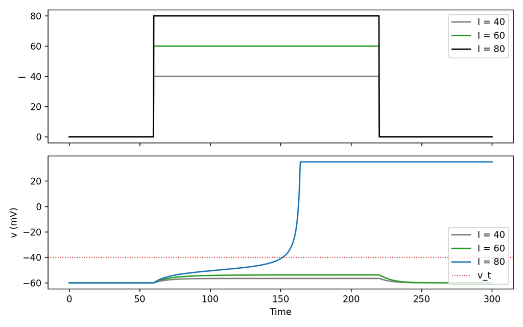

```python
T = 300.0
dt = 0.25
t = np.arange(0, T + dt, dt)
n = t.size

C = 100.0
k = 0.7
v_r = -60.0
v_t = -40.0
v_peak = 35.0

I = np.zeros((3, n))
I[0, (t >= 60) & (t < 220)] = 40.0
I[1, (t >= 60) & (t < 220)] = 60.0
I[2, (t >= 60) & (t < 220)] = 80.0

v = np.zeros((3, n))
v[:, 0] = v_r

for i in range(n - 1):
    for neuron in range(3):
        dvdt = (
            k * (v[neuron, i] - v_r) * (v[neuron, i] - v_t)
            + I[neuron, i]
        ) / C
        v[neuron, i + 1] = v[neuron, i] + dvdt * dt
        if v[neuron, i + 1] > v_peak:
            v[neuron, i + 1] = v_peak

fig, ax = plt.subplots(2, 1, sharex=True)
ax[0].plot(t, I[0], color="tab:gray", label="I = 40")
ax[0].plot(t, I[1], color="tab:green", label="I = 60")
ax[0].plot(t, I[2], color="black", label="I = 80")
ax[0].set_ylabel("I")
ax[0].legend(loc="upper right")

ax[1].plot(t, v[0], color="tab:gray", label="I = 40")
ax[1].plot(t, v[1], color="tab:green", label="I = 60")
ax[1].plot(t, v[2], color="tab:blue", label="I = 80")
ax[1].axhline(v_t, color="tab:red", linestyle=":", linewidth=1, label="v_t")
ax[1].set_ylabel("v (mV)")
ax[1].set_xlabel("Time")
ax[1].legend(loc="lower right")

plt.tight_layout()
plt.show()
```

The cap at `v_peak` is only for display. Without a reset rule, the quadratic equation can run away after strong depolarization.

#### Check your understanding

- Why does the voltage trajectory accelerate once it gets high enough?
- Is the display cap a biological mechanism?

**Show solution**

The factored quadratic term `k(v - v_r)(v - v_t)` makes the rate of voltage change depend nonlinearly on voltage. If `v_r < v_t`, then once voltage rises above the threshold-like value `v_t`, both `(v - v_r)` and `(v - v_t)` are positive. Their product grows faster than linearly as `v` increases, producing the accelerating upstroke. So `v_t` helps determine where acceleration begins, `k` helps determine how strongly it grows, and `I` and `u` help determine whether the trajectory reaches that region. The cap is not biological; it is only a plotting convenience before we introduce threshold and reset.

### Current pattern: short and long pulses

Compare pulse width next. The amplitude is the same, but the duration differs.

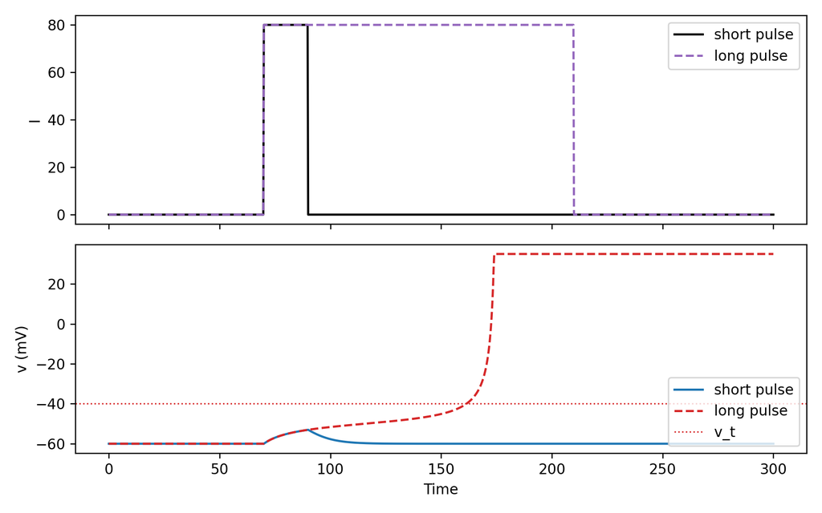

```python
I = np.zeros((2, n))
I[0, (t >= 70) & (t < 90)] = 80.0
I[1, (t >= 70) & (t < 210)] = 80.0

v = np.zeros((2, n))
v[:, 0] = v_r

for i in range(n - 1):
    for neuron in range(2):
        dvdt = (
            k * (v[neuron, i] - v_r) * (v[neuron, i] - v_t)
            + I[neuron, i]
        ) / C
        v[neuron, i + 1] = v[neuron, i] + dvdt * dt
        if v[neuron, i + 1] > v_peak:
            v[neuron, i + 1] = v_peak

fig, ax = plt.subplots(2, 1, sharex=True)
ax[0].plot(t, I[0], color="black", label="short pulse")
ax[0].plot(t, I[1], color="tab:purple", linestyle="--", label="long pulse")
ax[0].set_ylabel("I")
ax[0].legend(loc="upper right")

ax[1].plot(t, v[0], color="tab:blue", label="short pulse")
ax[1].plot(t, v[1], color="tab:red", linestyle="--", label="long pulse")
ax[1].axhline(v_t, color="tab:red", linestyle=":", linewidth=1, label="v_t")
ax[1].set_ylabel("v (mV)")
ax[1].set_xlabel("Time")
ax[1].legend(loc="lower right")

plt.tight_layout()
plt.show()
```

#### Predict and explain

Why can a longer pulse matter even when its amplitude is unchanged?

**Show solution**

The voltage is updated repeatedly while the pulse is on. A longer pulse gives the nonlinear dynamics more time to push the voltage into the accelerating part of the equation.

## 4. The full Izhikevich neuron

Now combine the factored quadratic voltage equation, the recovery variable, and a threshold-reset rule:

$$C\frac{dv}{dt} = k(v - v_r)(v - v_t) - u + I$$

$$\frac{du}{dt} = a\{b(v - v_r) - u\}$$

If `v >= v_peak`, record a spike, reset `v` to `c`, and increase `u` by `d`.

This form makes more of the modelling assumptions visible. The voltage equation is still a quadratic system, but now the roots of the quadratic are explicit. The value `v_r` is the resting-like voltage and `v_t` is the threshold-like voltage where the voltage trajectory can enter the accelerating region. The parameter `k` controls how steeply that acceleration grows. The parameter `C` scales the voltage response: for the same right-hand side, a larger `C` makes voltage change more slowly.

The recovery equation is also shifted by `v_r`. Instead of responding to raw voltage, `u` responds to voltage relative to rest, `v - v_r`. This means that recovery is tied to depolarization away from the resting-like voltage. The reset rule has two parts: `c` sends voltage back down after a spike, and `d` increases recovery after the spike.

### Current pattern: sustained step currents

Compare several sustained positive current steps.

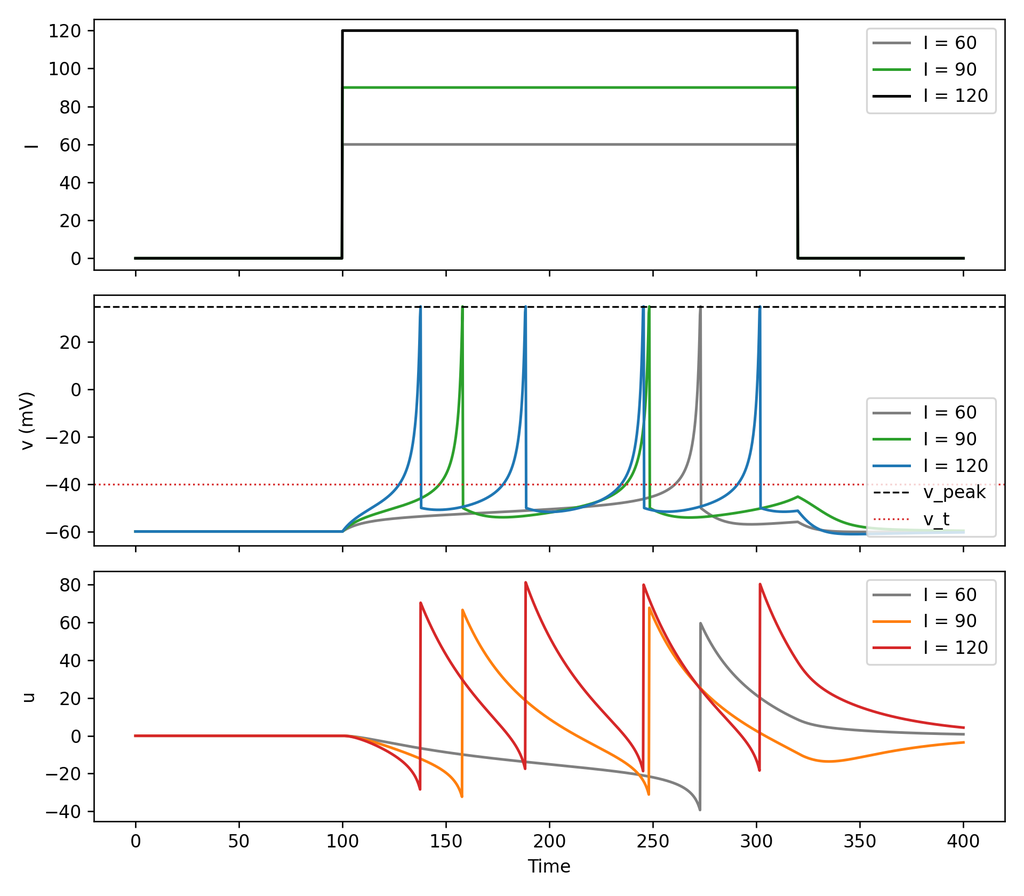

```python
T = 400.0
dt = 0.25
t = np.arange(0, T + dt, dt)
n = t.size

C = 100.0
k = 0.7
v_r = -60.0
v_t = -40.0
v_peak = 35.0
a = 0.03
b = -2.0
c = -50.0
d = 100.0

I = np.zeros((3, n))
I[0, (t >= 100) & (t < 320)] = 60.0
I[1, (t >= 100) & (t < 320)] = 90.0
I[2, (t >= 100) & (t < 320)] = 120.0

v = np.zeros((3, n))
u = np.zeros((3, n))
spk = np.zeros((3, n))
v[:, 0] = v_r
u[:, 0] = b * (v[:, 0] - v_r)

for i in range(n - 1):
    for neuron in range(3):
        dvdt = (
            k * (v[neuron, i] - v_r) * (v[neuron, i] - v_t)
            - u[neuron, i]
            + I[neuron, i]
        ) / C
        dudt = a * (b * (v[neuron, i] - v_r) - u[neuron, i])

        v[neuron, i + 1] = v[neuron, i] + dvdt * dt
        u[neuron, i + 1] = u[neuron, i] + dudt * dt

        if v[neuron, i + 1] >= v_peak:
            spk[neuron, i + 1] = 1.0
            v[neuron, i + 1] = c
            u[neuron, i + 1] = u[neuron, i + 1] + d

v_plot = v.copy()
v_plot[spk == 1.0] = v_peak

fig, ax = plt.subplots(3, 1, sharex=True, figsize=(8, 7))
ax[0].plot(t, I[0], color="tab:gray", label="I = 60")
ax[0].plot(t, I[1], color="tab:green", label="I = 90")
ax[0].plot(t, I[2], color="black", label="I = 120")
ax[0].set_ylabel("I")
ax[0].legend(loc="upper right")

ax[1].plot(t, v_plot[0], color="tab:gray", label="I = 60")
ax[1].plot(t, v_plot[1], color="tab:green", label="I = 90")
ax[1].plot(t, v_plot[2], color="tab:blue", label="I = 120")
ax[1].axhline(v_peak, color="black", linestyle="--", linewidth=1, label="v_peak")
ax[1].axhline(v_t, color="tab:red", linestyle=":", linewidth=1, label="v_t")
ax[1].set_ylabel("v (mV)")
ax[1].legend(loc="lower right")

ax[2].plot(t, u[0], color="tab:gray", label="I = 60")
ax[2].plot(t, u[1], color="tab:orange", label="I = 90")
ax[2].plot(t, u[2], color="tab:red", label="I = 120")
ax[2].set_ylabel("u")
ax[2].set_xlabel("Time")
ax[2].legend(loc="upper right")

plt.tight_layout()
plt.show()
```

#### Check your understanding

- Which current produces the most spikes?
- What happens to `u` after each spike?
- Why does increasing `u` tend to reduce excitability?

**Show solution**

The largest current produces the most spikes. After each spike, `u` jumps upward by `d`. Because the voltage equation contains `-u`, a larger `u` subtracts from the depolarizing drive and makes the neuron less excitable for a while.

Count spikes and estimate first-spike latency.

```python
for neuron, label in enumerate(["I = 60", "I = 90", "I = 120"]):
    spike_times = t[spk[neuron] == 1.0]
    spike_count = spike_times.size
    if spike_count > 0:
        first_latency = spike_times[0] - 100.0
        print(label, "spikes:", spike_count, "first-spike latency:", round(first_latency, 2))
    else:
        print(label, "spikes:", spike_count, "first-spike latency: no spike")
```

```
## I = 60 spikes: 1 first-spike latency: 173.0
## I = 90 spikes: 2 first-spike latency: 58.0
## I = 120 spikes: 4 first-spike latency: 37.75
```

#### Modify it

Change `d` from `100.0` to `40.0` and rerun the full neuron chunk. What should happen to adaptation?

**Show solution**

Smaller `d` means the recovery variable jumps less after each spike. The neuron should adapt less strongly and usually fire more readily during sustained input.

## 5. Same equation, different parameters

One strength of this model is that the same equation structure can produce different firing phenotypes. Here we compare a regular-spiking-like cell and a fast-spiking-like cell.

In this form, changing a cell type can mean changing both the voltage-shape parameters and the recovery/reset parameters. For example, a smaller `C` makes voltage respond more quickly, a larger `a` makes recovery faster, and a smaller `d` means less recovery is added after each spike. The point is not that one parameter alone defines a cell class. The firing pattern is produced by the combination of the voltage curve, recovery dynamics, reset voltage, and input.

### Current pattern: stronger sustained input

First, compare the two parameter sets with the same stronger sustained input.

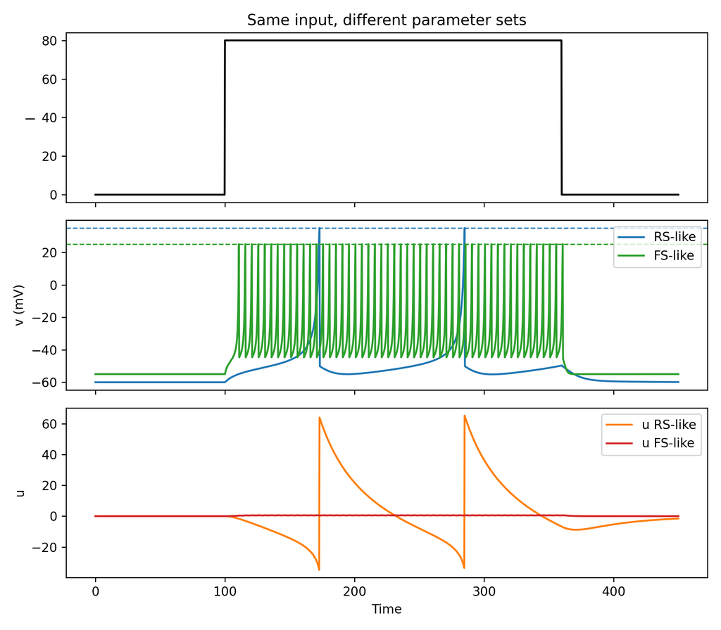

```python
T = 450.0
dt = 0.25
t = np.arange(0, T + dt, dt)
n = t.size

labels = ["RS-like", "FS-like"]
C_vals = np.array([100.0, 20.0])
k_vals = np.array([0.7, 1.0])
v_r_vals = np.array([-60.0, -55.0])
v_t_vals = np.array([-40.0, -40.0])
v_peak_vals = np.array([35.0, 25.0])
a_vals = np.array([0.03, 0.20])
b_vals = np.array([-2.0, 0.025])
c_vals = np.array([-50.0, -45.0])
d_vals = np.array([100.0, 0.0])

I = np.zeros(n)
I[(t >= 100) & (t < 360)] = 80.0

v = np.zeros((2, n))
u = np.zeros((2, n))
spk = np.zeros((2, n))
v[:, 0] = v_r_vals
u[:, 0] = b_vals * (v[:, 0] - v_r_vals)

for i in range(n - 1):
    for neuron in range(2):
        dvdt = (
            k_vals[neuron]
            * (v[neuron, i] - v_r_vals[neuron])
            * (v[neuron, i] - v_t_vals[neuron])
            - u[neuron, i]
            + I[i]
        ) / C_vals[neuron]
        dudt = a_vals[neuron] * (
            b_vals[neuron] * (v[neuron, i] - v_r_vals[neuron])
            - u[neuron, i]
        )

        v[neuron, i + 1] = v[neuron, i] + dvdt * dt
        u[neuron, i + 1] = u[neuron, i] + dudt * dt

        if v[neuron, i + 1] >= v_peak_vals[neuron]:
            spk[neuron, i + 1] = 1.0
            v[neuron, i + 1] = c_vals[neuron]
            u[neuron, i + 1] = u[neuron, i + 1] + d_vals[neuron]

v_plot = v.copy()
for neuron in range(2):
    v_plot[neuron, spk[neuron] == 1.0] = v_peak_vals[neuron]

fig, ax = plt.subplots(3, 1, sharex=True, figsize=(8, 7))
ax[0].plot(t, I, color="black")
ax[0].set_ylabel("I")
ax[0].set_title("Same input, different parameter sets")

ax[1].plot(t, v_plot[0], label=labels[0], color="tab:blue")
ax[1].plot(t, v_plot[1], label=labels[1], color="tab:green")
ax[1].axhline(v_peak_vals[0], color="tab:blue", linestyle="--", linewidth=1)
ax[1].axhline(v_peak_vals[1], color="tab:green", linestyle="--", linewidth=1)
ax[1].set_ylabel("v (mV)")
ax[1].legend(loc="upper right")

ax[2].plot(t, u[0], label="u RS-like", color="tab:orange")
ax[2].plot(t, u[1], label="u FS-like", color="tab:red")
ax[2].set_ylabel("u")
ax[2].set_xlabel("Time")
ax[2].legend(loc="upper right")

plt.tight_layout()
plt.show()
```

```python
for neuron, label in enumerate(labels):
    spike_times = t[spk[neuron] == 1.0]
    print(label, "spike count:", spike_times.size)
```

```
## RS-like spike count: 2
## FS-like spike count: 51
```

#### Check your understanding

- The input is identical. Why are the outputs different?
- Which voltage-shape or recovery parameter differs most strongly between the two cells?
- Which cell adapts more strongly after spikes?

**Show solution**

The outputs differ because several parameters change together. The FS-like cell has a much smaller `C`, so voltage responds more quickly to the same input. It also has a larger `a`, so recovery moves faster, and a much smaller `d`, so each spike adds less recovery. The RS-like cell has a larger post-spike recovery jump, which supports stronger spike-frequency adaptation.

### Current pattern: weaker near-threshold input

Now use a weaker input near threshold.

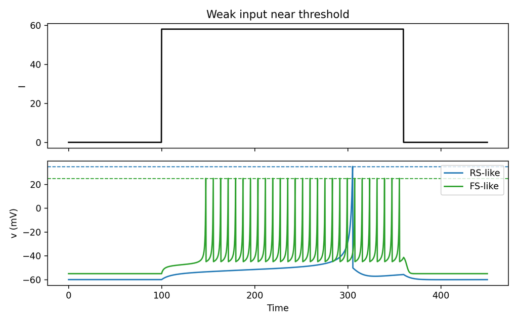

```python
I = np.zeros(n)
I[(t >= 100) & (t < 360)] = 58.0

v = np.zeros((2, n))
u = np.zeros((2, n))
spk = np.zeros((2, n))
v[:, 0] = v_r_vals
u[:, 0] = b_vals * (v[:, 0] - v_r_vals)

for i in range(n - 1):
    for neuron in range(2):
        dvdt = (
            k_vals[neuron]
            * (v[neuron, i] - v_r_vals[neuron])
            * (v[neuron, i] - v_t_vals[neuron])
            - u[neuron, i]
            + I[i]
        ) / C_vals[neuron]
        dudt = a_vals[neuron] * (
            b_vals[neuron] * (v[neuron, i] - v_r_vals[neuron])
            - u[neuron, i]
        )

        v[neuron, i + 1] = v[neuron, i] + dvdt * dt
        u[neuron, i + 1] = u[neuron, i] + dudt * dt

        if v[neuron, i + 1] >= v_peak_vals[neuron]:
            spk[neuron, i + 1] = 1.0
            v[neuron, i + 1] = c_vals[neuron]
            u[neuron, i + 1] = u[neuron, i + 1] + d_vals[neuron]

v_plot = v.copy()
for neuron in range(2):
    v_plot[neuron, spk[neuron] == 1.0] = v_peak_vals[neuron]

fig, ax = plt.subplots(2, 1, sharex=True)
ax[0].plot(t, I, color="black")
ax[0].set_ylabel("I")
ax[0].set_title("Weak input near threshold")

ax[1].plot(t, v_plot[0], label=labels[0], color="tab:blue")
ax[1].plot(t, v_plot[1], label=labels[1], color="tab:green")
ax[1].axhline(v_peak_vals[0], color="tab:blue", linestyle="--", linewidth=1)
ax[1].axhline(v_peak_vals[1], color="tab:green", linestyle="--", linewidth=1)
ax[1].set_ylabel("v (mV)")
ax[1].set_xlabel("Time")
ax[1].legend(loc="upper right")

plt.tight_layout()
plt.show()
```

```python
for neuron, label in enumerate(labels):
    print(label, "spike count:", int(spk[neuron].sum()))
```

```
## RS-like spike count: 1
## FS-like spike count: 27
```

#### Explain it

Why are near-threshold inputs useful for comparing excitability?

**Show solution**

Near threshold, small differences in parameters can change whether the cell spikes at all, how long it takes to spike, or whether it keeps firing. Strong inputs can make many cells fire and hide some of those differences.

## 6. MSN-like and cortical pyramidal-like responses

Finally, connect the model to next week. The parameter sets below are qualitative teaching examples, not biophysical fits. They are meant to show how different single-neuron response tendencies can matter before we place neurons into a basal ganglia circuit.

### Current pattern: matched input gains

First, compare the model cells with matched input amplitude.

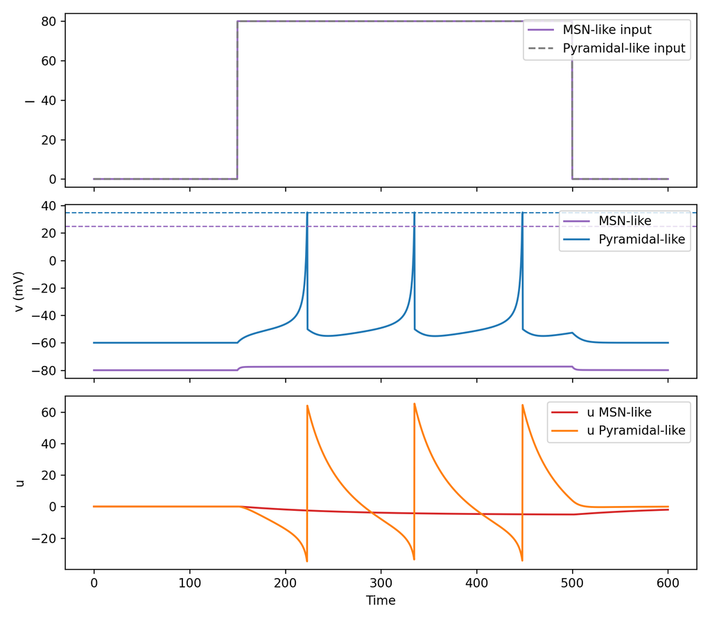

```python
T = 600.0
dt = 0.25
t = np.arange(0, T + dt, dt)
n = t.size

cell_labels = ["MSN-like", "Pyramidal-like"]
C_vals = np.array([80.0, 100.0])
k_vals = np.array([1.0, 0.7])
v_r_vals = np.array([-80.0, -60.0])
v_t_vals = np.array([-45.0, -40.0])
v_peak_vals = np.array([25.0, 35.0])
a_vals = np.array([0.01, 0.03])
b_vals = np.array([-2.0, -2.0])
c_vals = np.array([-75.0, -50.0])
d_vals = np.array([100.0, 100.0])

I_base = np.zeros(n)
I_base[(t >= 150) & (t < 500)] = 1.0
I_gain = np.array([80.0, 80.0])

v = np.zeros((2, n))
u = np.zeros((2, n))
spk = np.zeros((2, n))
v[:, 0] = v_r_vals
u[:, 0] = b_vals * (v[:, 0] - v_r_vals)

for i in range(n - 1):
    for neuron in range(2):
        I_now = I_base[i] * I_gain[neuron]
        dvdt = (
            k_vals[neuron]
            * (v[neuron, i] - v_r_vals[neuron])
            * (v[neuron, i] - v_t_vals[neuron])
            - u[neuron, i]
            + I_now
        ) / C_vals[neuron]
        dudt = a_vals[neuron] * (
            b_vals[neuron] * (v[neuron, i] - v_r_vals[neuron])
            - u[neuron, i]
        )

        v[neuron, i + 1] = v[neuron, i] + dvdt * dt
        u[neuron, i + 1] = u[neuron, i] + dudt * dt

        if v[neuron, i + 1] >= v_peak_vals[neuron]:
            spk[neuron, i + 1] = 1.0
            v[neuron, i + 1] = c_vals[neuron]
            u[neuron, i + 1] = u[neuron, i + 1] + d_vals[neuron]

v_plot = v.copy()
for neuron in range(2):
    v_plot[neuron, spk[neuron] == 1.0] = v_peak_vals[neuron]

fig, ax = plt.subplots(3, 1, sharex=True, figsize=(8, 7))
ax[0].plot(t, I_base * I_gain[0], color="tab:purple", label="MSN-like input")
ax[0].plot(t, I_base * I_gain[1], color="tab:gray", linestyle="--", label="Pyramidal-like input")
ax[0].set_ylabel("I")
ax[0].legend(loc="upper right")

ax[1].plot(t, v_plot[0], color="tab:purple", label="MSN-like")
ax[1].plot(t, v_plot[1], color="tab:blue", label="Pyramidal-like")
ax[1].axhline(v_peak_vals[0], color="tab:purple", linestyle="--", linewidth=1)
ax[1].axhline(v_peak_vals[1], color="tab:blue", linestyle="--", linewidth=1)
ax[1].set_ylabel("v (mV)")
ax[1].legend(loc="upper right")

ax[2].plot(t, u[0], color="tab:red", label="u MSN-like")
ax[2].plot(t, u[1], color="tab:orange", label="u Pyramidal-like")
ax[2].set_ylabel("u")
ax[2].set_xlabel("Time")
ax[2].legend(loc="upper right")

plt.tight_layout()
plt.show()
```

```python
for neuron, label in enumerate(cell_labels):
    print(label, "spike count:", int(spk[neuron].sum()))
```

```
## MSN-like spike count: 0
## Pyramidal-like spike count: 3
```

#### Check your understanding

- With matched input amplitude, do both model cells respond the same way?
- What does this tell you about using one current value for different cell classes?

**Show solution**

They do not respond the same way. A fixed current value is not automatically comparable across cell classes, because different values of `v_r`, `v_t`, `C`, `a`, `b`, `c`, and `d` can put the cells in different excitability regimes.

### Current pattern: compensated input gains

Now compensate the input so the MSN-like cell receives stronger drive.

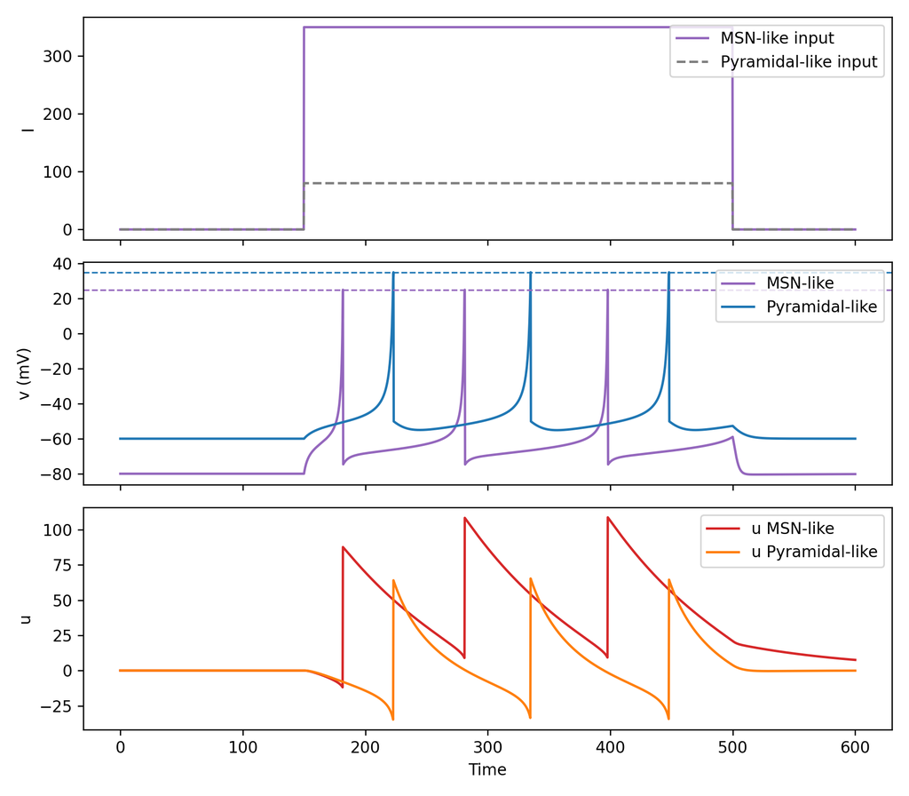

```python
I_base = np.zeros(n)
I_base[(t >= 150) & (t < 500)] = 1.0
I_gain = np.array([350.0, 80.0])

v = np.zeros((2, n))
u = np.zeros((2, n))
spk = np.zeros((2, n))
v[:, 0] = v_r_vals
u[:, 0] = b_vals * (v[:, 0] - v_r_vals)

for i in range(n - 1):
    for neuron in range(2):
        I_now = I_base[i] * I_gain[neuron]
        dvdt = (
            k_vals[neuron]
            * (v[neuron, i] - v_r_vals[neuron])
            * (v[neuron, i] - v_t_vals[neuron])
            - u[neuron, i]
            + I_now
        ) / C_vals[neuron]
        dudt = a_vals[neuron] * (
            b_vals[neuron] * (v[neuron, i] - v_r_vals[neuron])
            - u[neuron, i]
        )

        v[neuron, i + 1] = v[neuron, i] + dvdt * dt
        u[neuron, i + 1] = u[neuron, i] + dudt * dt

        if v[neuron, i + 1] >= v_peak_vals[neuron]:
            spk[neuron, i + 1] = 1.0
            v[neuron, i + 1] = c_vals[neuron]
            u[neuron, i + 1] = u[neuron, i + 1] + d_vals[neuron]

v_plot = v.copy()
for neuron in range(2):
    v_plot[neuron, spk[neuron] == 1.0] = v_peak_vals[neuron]

fig, ax = plt.subplots(3, 1, sharex=True, figsize=(8, 7))
ax[0].plot(t, I_base * I_gain[0], color="tab:purple", label="MSN-like input")
ax[0].plot(t, I_base * I_gain[1], color="tab:gray", linestyle="--", label="Pyramidal-like input")
ax[0].set_ylabel("I")
ax[0].legend(loc="upper right")

ax[1].plot(t, v_plot[0], color="tab:purple", label="MSN-like")
ax[1].plot(t, v_plot[1], color="tab:blue", label="Pyramidal-like")
ax[1].axhline(v_peak_vals[0], color="tab:purple", linestyle="--", linewidth=1)
ax[1].axhline(v_peak_vals[1], color="tab:blue", linestyle="--", linewidth=1)
ax[1].set_ylabel("v (mV)")
ax[1].legend(loc="upper right")

ax[2].plot(t, u[0], color="tab:red", label="u MSN-like")
ax[2].plot(t, u[1], color="tab:orange", label="u Pyramidal-like")
ax[2].set_ylabel("u")
ax[2].set_xlabel("Time")
ax[2].legend(loc="upper right")

plt.tight_layout()
plt.show()
```

```python
for neuron, label in enumerate(cell_labels):
    spike_times = t[spk[neuron] == 1.0]
    print(label, "spike count:", spike_times.size)
```

```
## MSN-like spike count: 3
## Pyramidal-like spike count: 3
```

#### Explain it

Why might we choose different input gains for different model cells in a teaching comparison?

**Show solution**

If the goal is to compare response patterns rather than simply show that one cell is harder to excite, different gains can put both cells into informative firing regimes. Here the MSN-like cell starts farther from its threshold-like region, so a larger input gain helps move it into a comparable range. The gain choice should be stated clearly so it is not mistaken for a biological fit.

## 7. What you should be able to do now

You should now be able to:

- Read an Euler update loop and identify the state variables.
- Explain what `v`, `u`, `I`, `a`, `b`, `c`, and `d` do in the Izhikevich model.
- Predict how stronger current changes firing.
- Count spikes and compare firing patterns.
- Explain why a single neuron model matters before building a network model.

### Final challenge

Choose one of the spiking examples above and change one parameter at a time:

- `a`: recovery speed
- `b`: coupling from voltage to recovery
- `c`: reset voltage
- `d`: recovery jump after a spike

For each change, write one sentence describing how the spike train changes.

**Show solution guide**

There is not one fixed answer because the result depends on the starting parameter set and current. A good answer should connect the parameter to an observed change. For example: increasing `d` usually strengthens adaptation because `u` jumps more after each spike; making `c` more negative resets the neuron farther from threshold; increasing `a` makes recovery move faster.